# Documentation *SampleTrackeR* script

**Version:** 1.0

**Author:** Dieter M. Tourlousse

**Contact information:** dieter.tourlousse@aist.go.jp

### Contents

This [R Markdown](http://rmarkdown.rstudio.com) document provides a basic description of `SampleTrackeR`, an R script for sample assurance in multiplexed high-throughput sequencing experiments, based on tagging of samples with synthetic spike-in controls mixtures, referred to as sample tracking mixtures (STMs).

### Prerequisites

`SampleTrackeR` depends on a small number of external R packages that need to be installed and loaded.

```r
suppressWarnings(suppressMessages(library(magrittr)))
suppressWarnings(suppressMessages(library(tidyr)))
suppressWarnings(suppressMessages(library(dplyr)))
suppressWarnings(suppressMessages(library(ggplot2)))
```

`SampleTrackeR` consists of a single script that can be loaded by sourcing the code.

```r
source("/absolute/path/to/SampleTrackeR.R")
```

Note that the script automatically sets the current directory as search path when looking for input files. All input files thus need to be present in the current directory.

### Description of input files

`SampleTrackeR` requires three different input files.

**`sample_plate_layout`**

This tab-delimited file describes the experimental setup, namely plate layout and STM added to each of the samples. Samples lacking STMs can be added using a *mock* STM (designated *e.g.* stm00); the mock STM composition should also be present in the `stm_compositions` file (see below for details).

The following columns and matching names are required.

- `libID`: name of the sample or sequencing library.
- `stmID`: identifier of the STM to added to the sample.
- `row`: row identifier (should be *integer*).
- `column`: column identifier (should be *integer*).

Other columns can be present (*e.g.*, *description* in the example table below); these are however ignored and not included in any of the generated output files.

| libID | description | stmID | row | column |
| --- | --- | --- | --- | --- |
| sam349 | a01 | stm33 | 1 | 4 |
| sam350 | a02 | stm34 | 2 | 4 |
| sam351 | a03 | stm35 | 3 | 4 |
| sam348 | a04 | stm36 | 4 | 4 |
| sam353 | a05 | stm37 | 5 | 4 |
| sam354 | a06 | stm38 | 6 | 4 |
| sam355 | a07 | stm39 | 7 | 4 |
| sam356 | a08 | stm40 | 8 | 4 |
| sam365 | a09 | stm41 | 1 | 5 |
| sam366 | a10 | stm42 | 2 | 5 |

**`read_count_table`**

This tab-delimited file represent a typical OTU read count table. Read counts for both the individual spike-in controls, as in the `stm_compositions` file (see below), and sample OTUs can be present. A column with name `otuID` is mandatory. The other column names represent sample identifiers as in the `sample_plate_layout` file (see above).

| otuID | sam396 | sam397 | sam398 | sam399 |
| --- | --- | --- | --- | --- |
| Bv5501 | 0 | 154 | 1 | 0 |
| Ca5501 | 0 | 0 | 0 | 0 |
| Ec5001 | 0 | 0 | 152 | 307 |
| Ec5002 | 35 | 0 | 0 | 0 |
| Ec5003 | 0 | 0 | 0 | 0 |
| Ec5004 | 0 | 0 | 0 | 0 |
| Ec5005 | 18 | 0 | 66 | 222 |
| Ec5501 | 0 | 0 | 0 | 0 |
| Ec5502 | 0 | 0 | 56 | 0 |
| Ec6001 | 27 | 188 | 0 | 0 |

[output cut: 3 more lines]

**`stm_compositions`**

This tab-delimited file represents a long-format table with the composition of the STMs.

The following columns and matching names are required.

- `stmID`: identifier of the STM
- `controlID`: identifier of the spike-in control
- `value`: value indicating wether the spike-in control is present in the STM (1: present and 0: absent)

| stmID | controlID | value |
| --- | --- | --- |
| stm01 | Bv5501 | 1 |
| stm01 | Ca5501 | 0 |
| stm01 | Ec5001 | 0 |
| stm01 | Ec5002 | 0 |
| stm01 | Ec5003 | 0 |
| stm01 | Ec5004 | 0 |
| stm01 | Ec5005 | 0 |
| stm01 | Ec5501 | 0 |
| stm01 | Ec5502 | 0 |
| stm01 | Ec6001 | 1 |

[output cut: 2 more lines]

To allow analysis of samples lacking spike-in controls, a mock STM (*e.g.* stm00) can be added with all values set to 0.

| stmID | controlID | value |
| --- | --- | --- |
| stm00 | Bv5501 | 0 |
| stm00 | Ec6001 | 0 |
| stm00 | Ga5501 | 0 |
| stm00 | Ca5501 | 0 |
| stm00 | Ec5002 | 0 |
| stm00 | Ec5501 | 0 |
| stm00 | Ec5001 | 0 |
| stm00 | Ec5005 | 0 |
| stm00 | Tb5501 | 0 |
| stm00 | Ec5003 | 0 |

[output cut: 2 more lines]

### General usage, output and terminology

```r
out <- SampleTrackeR(sample_plate_layout = "sample_plate_layout.txt",
                     read_count_table = "read_count_table.txt",
                     stm_compositions = "stm_compositions.txt",
                     read.threshold = 1,
                     fraction.threshold = 1)
```

**Description input arguments**

- `sample_plate_layout` (*required*) Name of tab-delimited file of sample layout.
- `read_count_table` (*required*) Name of tab-delimited file with read count data, including both synthetic spike-in controls and sample OTUs.
- `stm_compositions` (*required*) Name of tab-delimited file with STM compositions.
- `read.threshold` (*optional*) Minimum number of reads for a given spike-in control to be scored as present (default 1).
- `fraction.threshold` (*optional*) Minimum fraction of spike-in controls for a given STM to be scored as present in order for the STM to be scored as present (default 1).

**Description outputs**

The output of `SampleTrackeR` is a list with four different objects. Assuming that the output list is called `out`, the resultant list contains the following:

- `out$tab1`, a data frame containing a summary of sample identification based on majority STMs.
- `out$plot1`, a ggplot2 object visualizing the output of the sample identification portion of the script.
- `out$tab2`, a data frame containing a summary of between-sample carry-over based on minority STMs.
- `out$plot2`, a ggplot2 object visualizing the output of the between-sample carry-over portion of the script.

Note that `out$tab2` and `out$plot2` are *not* generated when no minority STMs are identified in any of the samples. In this case, a message will be output stated that between-sample carry-over was not evaluated, and hence assurmed to be minimal based on the lack of minority STMs.

**Terminology**

- `majority_STM`, refers to the STM with the highest cumulative read count in a given sample. The majority STM is used to assign sample identity and detect/resolve potential sample swaps.
- `minority_STM`, refers to STMs present in a sample, excluding the majority STM. A sample can contain multiple minority STMs and these are used for assessment of between-sample carry-over (that is, cross-contamination).
- `distinguishing_controls`, refers to the number of individual spike-in controls that are not shared between two different STMs. For evaluation of between-sample carry-over, the number of distinguishing controls is the number of spike-in controls present in the minority STM but absent in the majority STM.
- `percent_carryover`, refers to the estimated amount of sample carry-over between two samples, as quantified based on minority STMs.

### Examples

In this section, we apply the script to several datasets presented in the accompanying manuscript.

**[1] Identification of swapped samples**

For this experiment, unique STMs were individually added to 16 aliquots of DNA extracted from a single soil sample. Tube labels were then switched to mimic swapping or mislabeling of samples.

```r
out <- SampleTrackeR(sample_plate_layout = "sample_plate_layout1.txt",
                     read_count_table = "read_count_table1.txt",
                     stm_compositions = "stm_compositions.txt",
                     read.threshold = 1,
                     fraction.threshold = 1)
```

```
Based on the majority STMs, it appears that 8 samples may have been mislabeled/swapped.
 ... The expected STMs will be updated based on the identified majority_STM for subsequent assessment of between-sample carry-over ...

No minority STMs were identified in any of the samples.
 ...Evaluation of between-sample carry-over was not performed ...
```

As expected, `SampleTrackeR` returns an output message indicating that multiple samples have been swapped, in this case 8 samples out of 16 samples.

In addition, `SampleTrackeR` indicates that no minority STMs were identified in any of the samples, suggesting that between-sample carry-over was, if present, below the limit of detection.

Focusing on the results related to sample swapping / mislabeling, relevant output can be found in `out$tab1`:

```r
as_tibble(out$tab1)
```

| libID | expected.stm_ID | total.reads | total.control.reads | majority.stm_ID | majority.stm_reads | majority.stm_prevalence | qc.passed |
| --- | --- | --- | --- | --- | --- | --- | --- |
| sam396 | stm04 | 571839 | 80 | stm12 | 80 | 1 | NO |
| sam397 | stm01 | 335927 | 473 | stm01 | 473 | 1 | yes |
| sam398 | stm02 | 259412 | 275 | stm10 | 274 | 1 | NO |
| sam399 | stm03 | 516243 | 725 | stm03 | 725 | 1 | yes |
| sam401 | stm05 | 740905 | 857 | stm05 | 857 | 1 | yes |
| sam402 | stm06 | 77333 | 68 | stm14 | 68 | 1 | NO |
| sam403 | stm07 | 485237 | 331 | stm07 | 331 | 1 | yes |
| sam404 | stm08 | 342605 | 276 | stm16 | 275 | 1 | NO |
| sam412 | stm12 | 115271 | 78 | stm04 | 77 | 1 | NO |
| sam414 | stm10 | 91698 | 74 | stm02 | 74 | 1 | NO |

[output cut: 6 more lines]

From this table, swapped samples can be extracted as follows:

```r
swapped <- out$tab1[out$tab1$qc.passed == "NO", ][,c(1,2,5)]
as_tibble(swapped)
```

|  | libID | expected.stm_ID | majority.stm_ID |
| --- | --- | --- | --- |
| 1 | sam396 | stm04 | stm12 |
| 2 | sam398 | stm02 | stm10 |
| 3 | sam402 | stm06 | stm14 |
| 4 | sam404 | stm08 | stm16 |
| 5 | sam412 | stm12 | stm04 |
| 6 | sam414 | stm10 | stm02 |
| 7 | sam418 | stm14 | stm06 |
| 8 | sam482 | stm16 | stm08 |

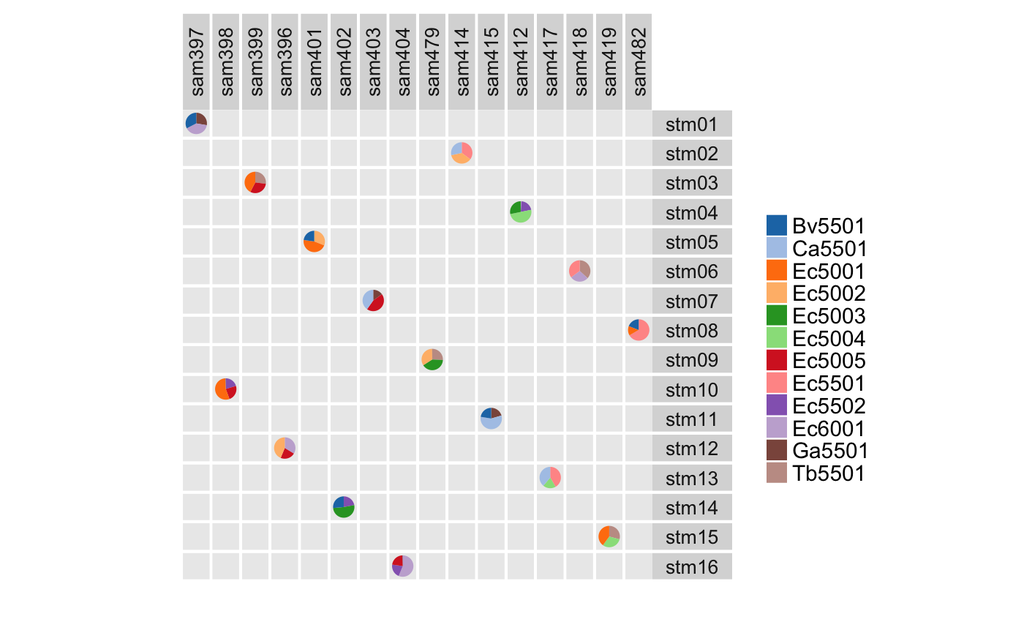

```r
out$plot1 +
  theme(legend.key.size=unit(0.8,"line")) +
  theme(strip.text = element_text(size=10)) +
  ggthemes::scale_fill_tableau("tableau20")
```

In this plot, samples that are swapped are located on the off-diagional, revealing the identity of the swapped samples. In all cases, identified swaps and their STM-based reassignments in all cases agreed with the (single-blinded) experimental design.

**[2] Identification and quantification of between-sample cross-contamination**

For this experiment, two different STMs were added to DNA extracted from two contrasting microbiota, namely from sewage (DNA spiked with stm88) and soil (DNA spiked with stm89). Artificially contaminated samples were then prepared by mixing both STM-tagged samples in varying ratios, from 50% to 0.01% of soil DNA diluted in sewage DNA.

```r
out <- SampleTrackeR(sample_plate_layout = "sample_plate_layout2.txt",
                     read_count_table = "read_count_table2.txt",
                     stm_compositions = "stm_compositions.txt",
                     read.threshold = 1,
                     fraction.threshold = 1)
```

As expected, `SampleTrackeR` revealed that multiple samples were cross-contaminated. Relevant data can be found in `out$tab2`:

```r
as_tibble(out$tab2) %>%
  dplyr::filter(carryover_estimated.percent > 0)
```

| libID | majority.stm_ID | minority.stm_ID | majority.stm_reads | minority.stm_reads | distinguishing.controls | carryover_estimated.percent | carryover_number.reads |
| --- | --- | --- | --- | --- | --- | --- | --- |
| sam428 | stm88 | stm89 | 1188 | 124 | 3 | 9.4512195 | 124 |
| sam433 | stm88 | stm89 | 993 | 7 | 3 | 0.7000000 | 7 |
| sam447 | stm89 | stm88 | 164 | 162 | 3 | 49.6932515 | 162 |
| sam476 | stm88 | stm89 | 960 | 923 | 3 | 49.0175252 | 923 |
| sam481 | stm88 | stm89 | 1888 | 10 | 3 | 0.5268704 | 10 |
| sam483 | stm88 | stm89 | 1255 | 7 | 3 | 0.5546751 | 7 |
| sam484 | stm88 | stm89 | 1758 | 216 | 3 | 10.9422492 | 216 |

In this case, the number of `distinguishing controls` is 3 as the two STMs used in this experiment were selected to lack shared spike-in controls.

**[3] Case demonstration**

```r
out <- SampleTrackeR(sample_plate_layout = "sample_plate_layout3.txt",
                     read_count_table = "read_count_table3.txt",
                     stm_compositions = "stm_compositions.txt",
                     read.threshold = 1,
                     fraction.threshold = 1)
```

```
Based on the identified majority STMs, no samples appear to have been swapped/mislabeled.
Based on the identified minority STMs, 7 potential cases of between-sample carry-over have been identified.
```

Here, `SampleTrackeR` indicated no cases of sample swapping, which was expected given that the experiment was performed using an automated liquid handling station.

```r
out$plot1 +
  theme(legend.key.size=unit(0.8,"line")) +
  theme(strip.text = element_text(size=10))+
  ggthemes::scale_fill_tableau("tableau20")
```

[output not shown]

However, multiple cases of potential between-sample carry-over were identified.

```r
as_tibble(out$tab2) %>%
  dplyr::mutate_if(is.factor, as.character) %>%
  dplyr::filter(carryover_estimated.percent > 0)
```

| libID | majority.stm_ID | minority.stm_ID | majority.stm_reads | minority.stm_reads | distinguishing.controls | carryover_estimated.percent | carryover_number.reads |
| --- | --- | --- | --- | --- | --- | --- | --- |
| sam300 | stm20 | stm08 | 1951 | 1579 | 1 | 0.26737968 | 1 |
| sam300 | stm20 | stm45 | 1951 | 972 | 1 | 0.10193680 | 1 |
| sam300 | stm20 | stm60 | 1951 | 982 | 2 | 0.20554985 | 2 |
| sam300 | stm20 | stm78 | 1951 | 1354 | 1 | 0.16694491 | 1 |
| sam300 | stm20 | stm81 | 1951 | 972 | 1 | 0.10193680 | 1 |
| sam300 | stm20 | stm83 | 1951 | 1579 | 1 | 0.26737968 | 1 |
| sam300 | stm20 | stm90 | 1951 | 375 | 2 | 0.12658228 | 2 |
| sam302 | stm18 | stm01 | 9668 | 6440 | 1 | 0.03095975 | 1 |
| sam306 | stm22 | stm13 | 2056 | 1415 | 1 | 0.15552100 | 1 |
| sam307 | stm23 | stm66 | 2946 | 1950 | 1 | 0.39840637 | 4 |

[output cut: 19 more lines]

Here, the number of `distinguishing controls` can be less than 3 since STMs may share spike-in controls.

Based on the plate layout, the `SampleTrackeR` generates a plot of potential contamination sources that can be found in in `out$plot2`:

```r
out$plot2 +
  ggthemes::scale_color_tableau("tableau10") +
  theme(legend.title = element_blank()) +
  xlab("column") + ylab("row")
```

[output not shown]